# week5_part1

Craig Kopulsky

2/13/2021

```r
energy <- read.csv(here("data", "energy.csv"))
```

```r
energy_ts <- energy %>%
  mutate(date = tsibble::yearmonth(month)) %>%
  as_tsibble(key = NULL, index = date)
```

# Raw data graph

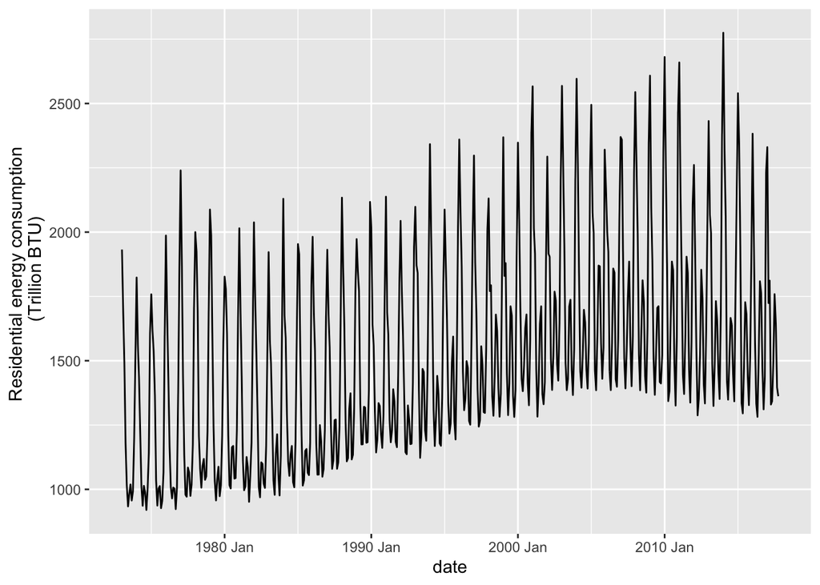

```r
ggplot(data = energy_ts, aes(x = date, y = res_total)) +
  geom_line() +
  labs(y = "Residential energy consumption \n (Trillion BTU)")
```

Looks like there are some interesting things happening. We should ask:

```
Is there an overall trend?
Is there seasonality?
Any cyclicality evident?
Any other notable patterns, outliers, etc.?
```

The big ones to notice quickly here are:

```
Overall increasing trend overall, but stability (and possibly a slight decreasing trend) starting around 2005
Clear seasonality, with a dominant seasonal feature and also a secondary peak each year - that secondary peak has increased substantially
No notable cyclicality or outliers
```

# Exploratory Time Series Visualization

## Seasonplot:

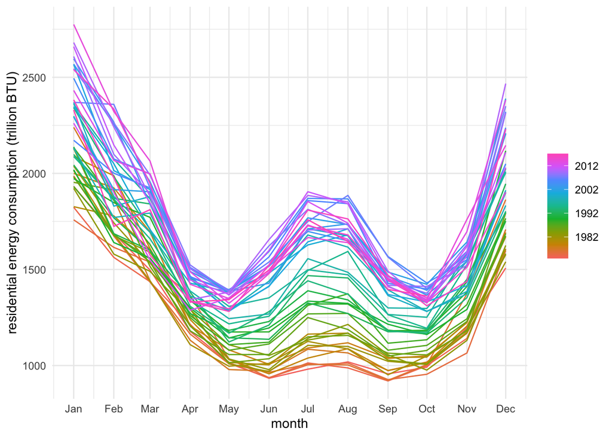

```r
energy_ts %>%
  gg_season(y = res_total) +
  theme_minimal() +
  labs(x = "month",
       y = "residential energy consumption (trillion BTU)")
```

This is really useful for us to explore both seasonal patterns, and how those seasonal patterns have changed over the years of this data (1973 - 2017). What are the major takeaways from this seasonplot?

```
The highest residential energy usage is around December / January / February
There is a secondary peak around July & August (that’s the repeated secondary peak we see in the original time series graph)
We can also see that the prevalence of that second peak has been increasing over the course of the time series: in 1973 (orange) there was hardly any summer peak. In more recent years (blue/magenta) that peak is much more prominent.
```

## Subseries plot

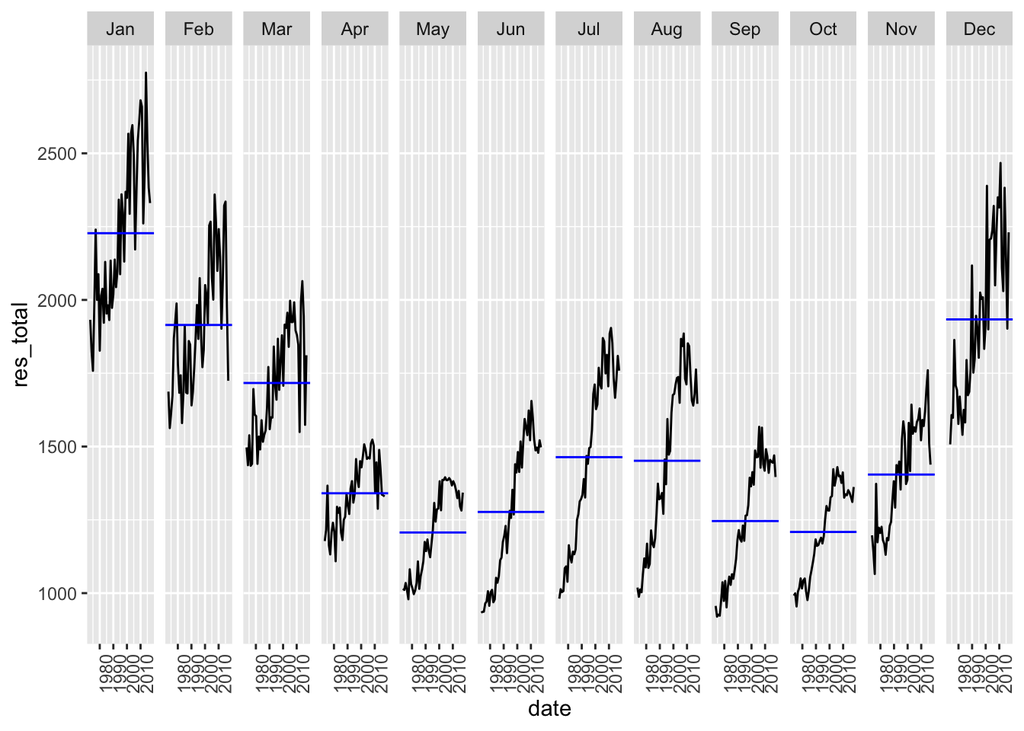

```r
energy_ts %>% gg_subseries(res_total)
```

Our takeaway here is similar: there is clear seasonality (higher values in winter months), with an increasingly evident second peak in June/July/August. This reinforces our takeaways from the raw data and seasonplots.

## Decomposition (here by STL)

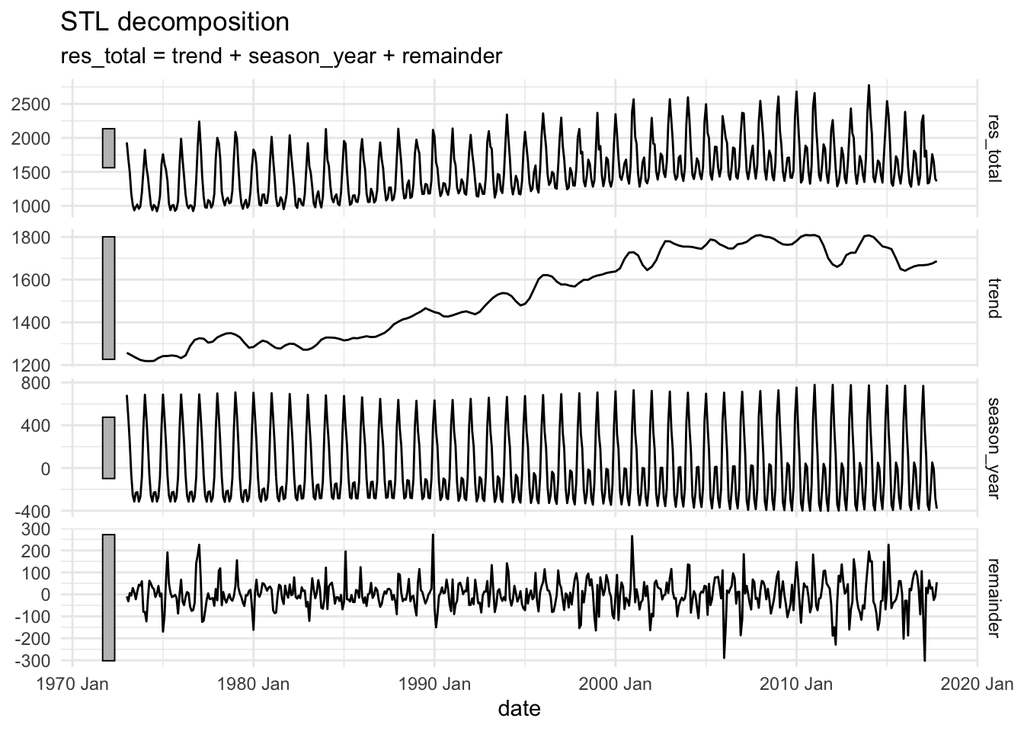

```r
# Find STL decomposition
dcmp <- energy_ts %>%
  model(STL(res_total ~ season()))

# View the components
# components(dcmp)

# Visualize the decomposed components
components(dcmp) %>%  autoplot() +
  theme_minimal()
```

## Autocorrelation function (ACF)

We use the ACF to explore autocorrelation (here, we would expect seasonality to be clear from the ACF):

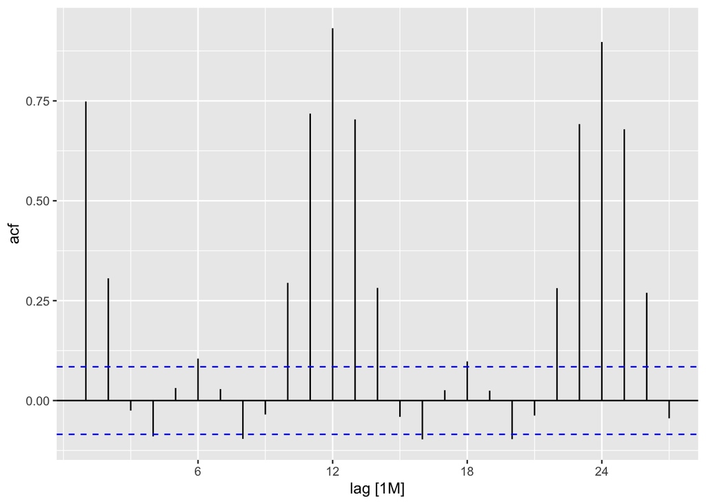

```r
energy_ts %>%
  ACF(res_total) %>%
  autoplot()
```

And yep, we see that observations separated by 12 months are the most highly correlated, reflecting strong seasonality we see in all of our other exploratory visualizations.

# Forecasting by Holt-Winters exponential smoothing

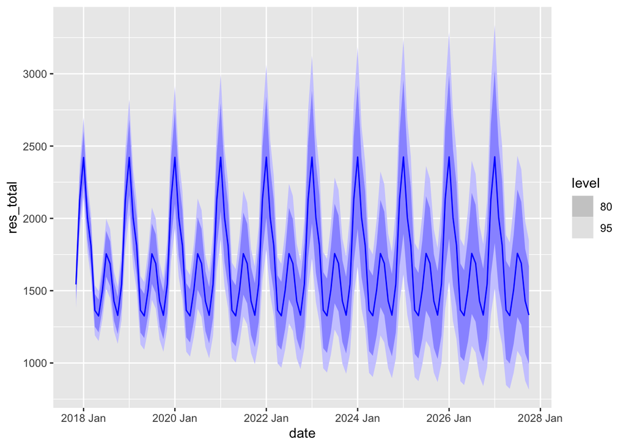

```r
# Create the model:
energy_fit <- energy_ts %>%
  model(
    ets = ETS(res_total ~ season("M"))
  )

# Forecast using the model 10 years into the future:
energy_forecast <- energy_fit %>%
  forecast(h = "10 years")

# Plot just the forecasted values (with 80 & 95% CIs):
energy_forecast %>%
  autoplot()
```

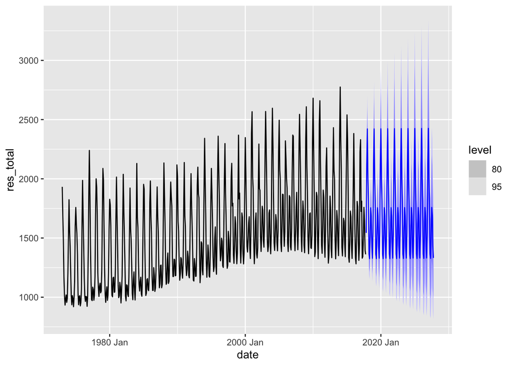

```r
# Or plot it added to the original data:
energy_forecast %>%
  autoplot(energy_ts)
```

## Assessing residuals

```r
# Append the predicted values (and residuals) to original energy data
energy_predicted <- broom::augment(energy_fit)

# Use View(energy_predicted) to see the resulting data frame
```

Now, plot the actual energy values (res_total), and the predicted values (stored as .fitted) atop them:

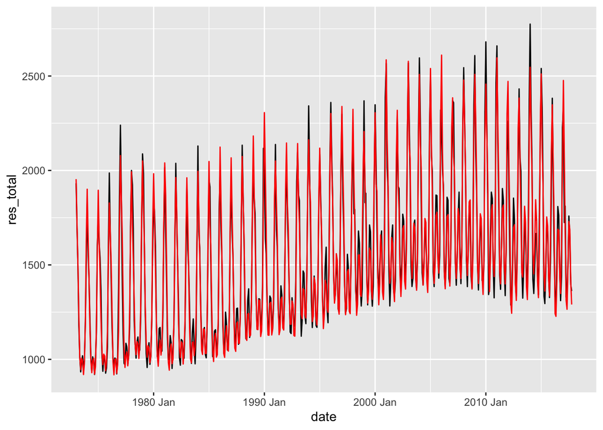

```r
ggplot(data = energy_predicted) +
  geom_line(aes(x = date, y = res_total)) +
  geom_line(aes(x = date, y = .fitted), color = "red")
```

Now let’s explore the residuals. Remember, some important considerations: Residuals should be uncorrelated, centered at 0, and ideally normally distributed. One way we can check the distribution is with a histogram:

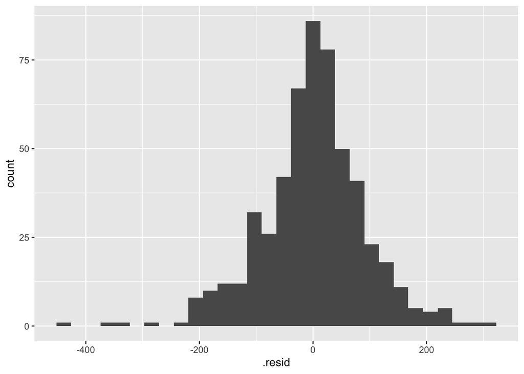

```r
ggplot(data = energy_predicted, aes(x = .resid)) +
  geom_histogram()
```

We see that this looks relatively normally distributed, and centered at 0 (we could find summary statistics beyond this to further explore).